[← Volver a Día 1](https://valentinzarate.github.io/taller_mov/tema_1/tema1.html)

# Números Complejos

## 1.1 ¿Por qué números complejos?

En ecología de movimientos, al igual que en cualquier análisis con datos espaciales, cada observación se describe mediante una ubicación en el plano, definida por dos coordenadas, por ejemplo *x* e *y*. Antes de entrar en trayectorias y sus dinámicas temporales, es útil reconocer que muchas preguntas ecológicas comienzan simplemente con un conjunto de puntos en un espacio bidimensional.

Este es el punto de partida tanto de la ecología espacial como del análisis de procesos puntuales (Point Process Analysis, PPA), donde el interés está en cómo se distribuyen los puntos en el plano: si están agrupados, dispersos o distribuidos al azar.

En ese contexto, cada observación generalmente suele pensarse como un conjunto de pares ordenados $(x,y)$, sin considerar todavía el tiempo ni el orden en que esos puntos fueron generados.

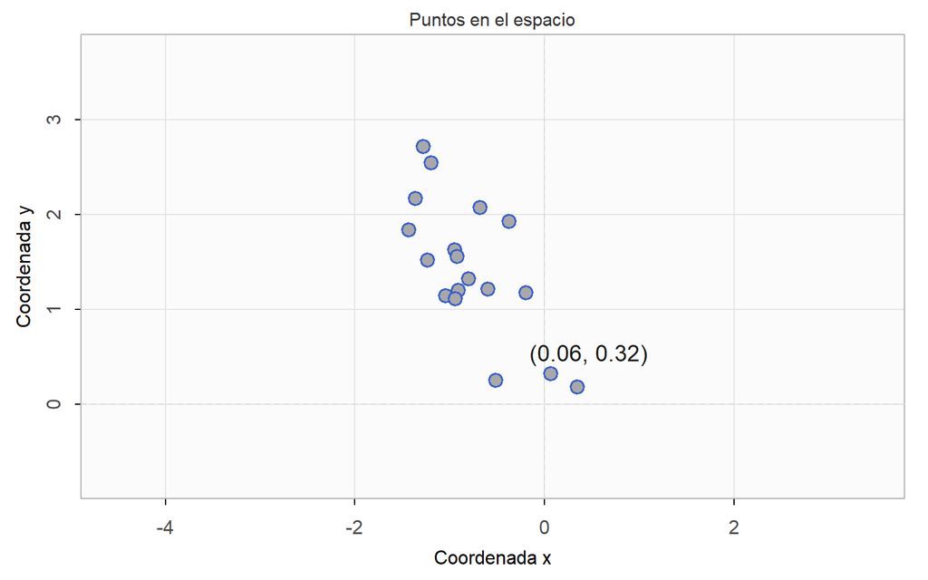

La ecología de movimientos parte de la misma base, pero al agregar la dimensión “tiempo”, en lugar de un conjunto de puntos independientes, se trabaja con una secuencia ordenada de posiciones, es decir, una trayectoria. En estos casos los cambios secuenciales entre puntos son el centro de todo… incluyendo rotaciones, escaladas y transformaciones.Es decir, en eco de movimientos la unidad operacional de donde salen todos los análisis son **los vectores**.

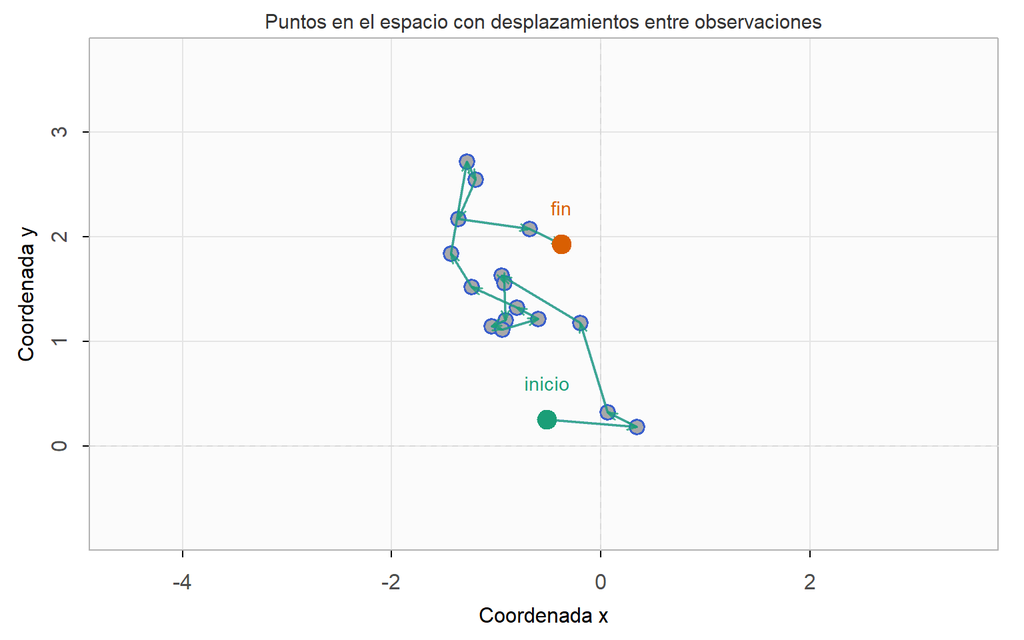

Aca es donde entra el conjunto de los numeros complejos $\mathbb{C}$. Los numeros complejos no son una cosa rara inmanejable, simplemente extienden el sistema númerico más allá del conjunto de los números reales $\mathbb{R}$. Los numeros complejos tienen propiedades distintas a los reales y por esto aportan una regla de multiplicación a los reales para poder naturalmente operar en un plano de dos dimensiones. Es decir, el punto (*x*,*y*) ya existe en $\mathbb{R}$, pero para mover ese punto en el espacio y calcular varias cosas tenemos que empezar a usar distintos teoremas externos y hacerlo para dos conjutos a la vez ($x$ e $y$). En otras palabras, $i$ conecta a los numeros reales $x$ e $y$ dandoles ortogonalidad y rotación nautal mediante pasos alegebraícos simples y directos.

Históricamente, esta limitación aparece al intentar resolver ecuaciones simples que no tienen solución en los reales, como

$$x^2 + 1 = 0$$

Para poder resolver este tipo de problemas, se introduce un nuevo número, $i$, definido por

$$i^2 = -1$$

Lo que en principio era una solución algebraica muy putnual, terminó generando algo mucho más util. A partir de este nuevo elemento, matemáticos como Euler y Gauss muestran que estos números no sólo sirven para cerrar ecuaciones inconculsas, sino que pueden interpretarse geométricamente como puntos en un plano.

En otras palabras, $i$ permite que el punto en el espacio ($x$ , $y$) pueda transformarse mediante algebra compleja (no díficil) como una sola cosa, y no tener que estar computando dos ecuaciones independientes. Por eso, los números complejos son la base de cualquier proceso de puntos de ecologiía espacial (y consecuentemente de movimeintos) y dan la base a teoria de proyeccion de mapas y muchas cosas mas. [Stachova (2010)](https://komunikacie.uniza.sk/pdfs/csl/2010/01/07.pdf) por si quieren sufrir.

Entonces, lo que vamos a intetar hacer ahora, y como se hace en la mayoría de las funciones de ecología de movimietos, es implementar todas las operaciones sobre $z$, no sobre $x$ e $y$:

$z = a + bi$

donde:

- $a \in \mathbb{R}$ es la **parte real**,
- $b \in \mathbb{R}$ es la **parte imaginaria**,
- $i$ es la unidad imaginaria, definida por la propiedad

$i^2 = -1$

$a = a + 0i$

## 1.1 Interpretación geométrica y rotación

La clave conceptual es que un número complejo es una forma de representar un vector en el plano. Si escribimos

$$z = a + bi$$

entonces podemos asociarlo directamente al punto o vector $(a,b)$ en un plano cartesiano: la parte real define el eje horizontal y la parte imaginaria el eje vertical.

El aporte más novedoso y útil esta asociado a lo que significa multiplicar un $Z$ cualquiera por $i$

Si tomamos un número complejo cualquiera

$$z = a + bi$$

y lo multiplicamos por $i$, obtenemos

$$i z = i(a + bi) = ai + b i^2 = -b + ai$$

Es decir, el punto $(a,b)$ se transforma en $(-b,a)$. Geométricamente, esto corresponde exactamente a una **rotación de 90° en sentido antihorario** en el plano.

Multiplicar por $i$ rota vectores. Básicamente al multiplicar por $i$ estamos transformando posiciones en el espacio.

Esto conecta directamente con cómo describimos movimiento: cambios de dirección pueden interpretarse como rotaciones de vectores en el plano.

## 1.2 Rotación y la fórmula de Euler

Si multiplicar por $i$ genera una rotación de 90°, pero entonces ¿cómo representar una rotación de cualquier ángulo $\theta$?

La respuesta la da la fórmula de Euler, que establece que:

$$e^{i\theta} = \cos\theta + i\sin\theta$$

Esta expresión conecta exponenciales, trigonometría y números complejos en una sola estructura.

Multiplicar un número complejo por $e^{i\theta}$ produce una rotación de ángulo $\theta$ sin cambiar su magnitud. Es decir, si

$$z = a + bi$$

entonces

$$z' = z \cdot e^{i\theta}$$

es el mismo vector rotado un ángulo $\theta$ en el plano.

En particular, si $\theta = \frac{\pi}{2}$:

$$e^{i\frac{\pi}{2}} = i$$

lo que recupera exactamente el resultado anterior: multiplicar por $i$ es una rotación de 90°.

## 1.3 Operaciones básicas

La suma de complejos se define componente a componente. Si

$$z_1 = a + bi \qquad \text{y} \qquad z_2 = c + di$$

entonces

$$z_1 + z_2 = (a+c) + (b+d)i$$

Esto equivale a sumar vectores en el plano, es decir, combinar desplazamientos.

La multiplicación, en cambio, combina escala y rotación. Se define como:

$$(a+bi)(c+di) = (ac-bd) + (ad+bc)i$$

y es precisamente esta operación la que permite modelar cambios de orientación en el espacio.

## 1.4 Módulo y argumento

Un número complejo también puede describirse en términos de su magnitud y su dirección. Esto se conecta muy muy directametne con ecología de movimientos.

Cómo podemos definir un vector en el plano bidimiancional como $Z= x +iy$, el **módulo** de $Z$ representa la longitud del vector:

$$|z| = \sqrt{a^2 + b^2}$$

Por otro lado, el **argumento** es el ángulo que forma con el eje horizontal:

$$\theta = \tan^{-1}\left(\frac{b}{a}\right)$$

En la práctica, se utiliza `atan2(b,a)` para obtener el ángulo correcto en todos los cuadrantes.

Con estas dos cantidades, el número complejo puede escribirse como:

$$z = r(\cos\theta + i\sin\theta) = r e^{i\theta}$$

donde $r = |z|$.

## 1.5 Por qué esto es importante

Los números complejos permiten representar en una sola estructura matemática lo que en coordenadas cartesianas aparece separado: posición, magnitud y dirección.

Un punto $(x,y)$ pasa a ser $z = x + yi$, pero además ahora podemos:

- sumar desplazamientos (suma de complejos),
- medir distancias entre un punto y otro (módulo),
- obtener direcciones (argumento),
- y rotar vectores (multiplicación por $e^{i\theta}$).

Este marco conceptual es exactamente el que se utiliza al trabajar con coordenadas cartesianas proyectadas, como por ejemplo en sistemas UTM, donde el espacio se representa como un plano sobre el cual se calculan trayectorias, distancias y direcciones.

En ecología de movimientos, esto permite pasar de una secuencia de puntos a una descripción matemática coherente del movimiento en términos de desplazamientos y cambios de dirección.

## 1.6 Largo de los pasos y ángulos de giro

Una vez que una localización se representa como un número complejo,

$$z_t = x_t + i y_t$$

cada observación pasa a ser un punto en el plano cartesiano. Esto permite describir el movimiento entre dos tiempos consecutivos como un **desplazamiento**, es decir, como la diferencia entre dos posiciones:

$$\Delta z_t = z_{t+1} - z_t$$

Este desplazamiento contiene dos piezas de información fundamentales en ecología de movimientos:

- su **módulo**, que corresponde al **largo del paso**,
- y su **argumento**, que corresponde a la **dirección** del desplazamiento.

A partir de ahí, el **ángulo de giro** puede entenderse como el cambio de dirección entre dos desplazamientos consecutivos. Esta es una de las razones por las cuales la representación compleja es tan útil: distancia, dirección y rotación quedan integradas en una misma estructura algebraica.

Antes de pasar a una trayectoria completa, conviene visualizar primero la idea básica de rotación en el plano complejo.

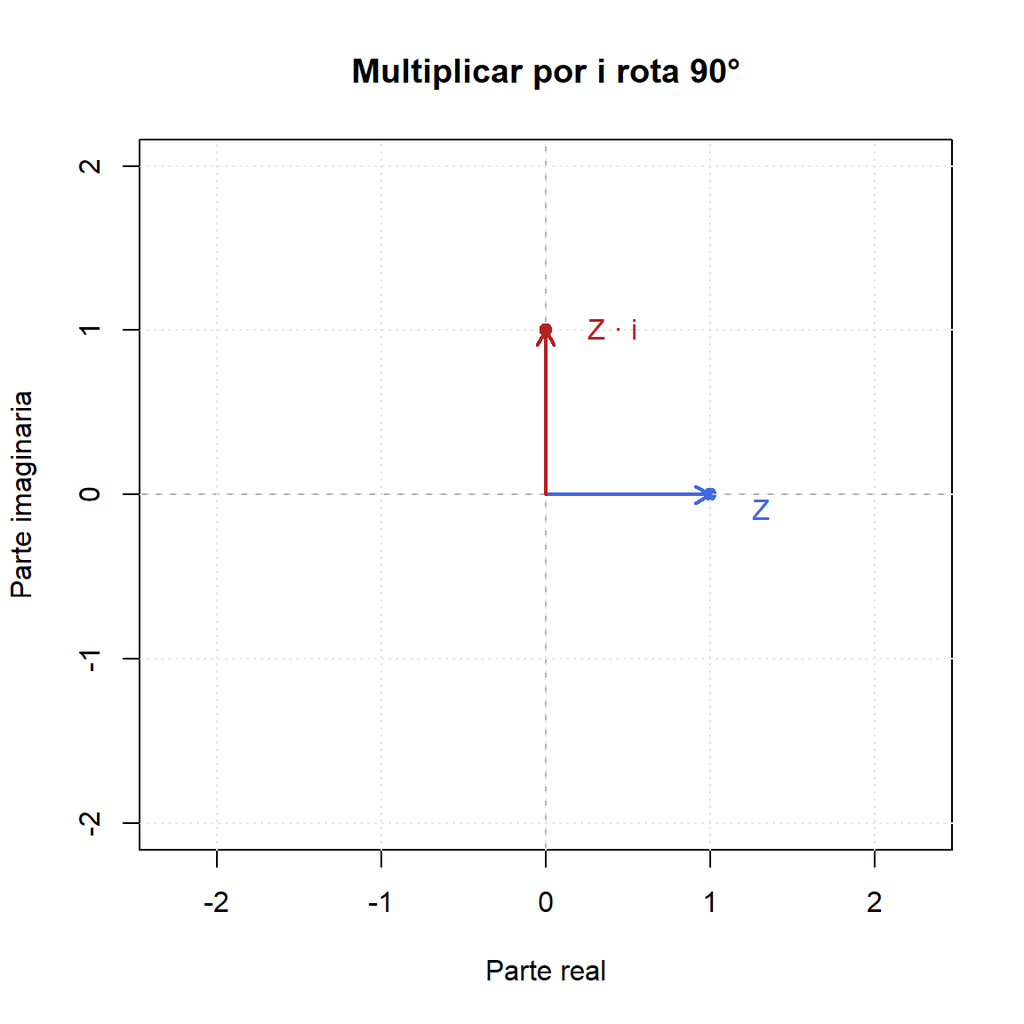

```r
X <- 1
Y <- 0
Z <- complex(real = X, imaginary = Y)

# o lo mismo poner

Z <- X +1i * Y

Z_rotated <- Z * complex(real = 0, imaginary = 1)


# o simplemente

Z_rotated <- Z * 1i #Z_rotated <- (X + 1i * Y) * 1i, tamb podría ser...

plot(Re(Z), Im(Z),
     xlim = c(-2, 2), ylim = c(-2, 2),
     xlab = "Parte real", ylab = "Parte imaginaria",
     main = "Multiplicar por i rota 90°",
     pch = 19, col = "royalblue",
     asp = 1)

abline(h = 0, v = 0, col = "gray70", lty = 2)
grid(col = "gray90")

arrows(0, 0, Re(Z), Im(Z), col = "royalblue", lwd = 2, length = 0.1)
points(Re(Z_rotated), Im(Z_rotated), pch = 19, col = "firebrick")
arrows(0, 0, Re(Z_rotated), Im(Z_rotated), col = "firebrick", lwd = 2, length = 0.1)

text(Re(Z) + 0.15, Im(Z) - 0.1, labels = "Z", col = "royalblue", pos = 4)
text(Re(Z_rotated) + 0.15, Im(Z_rotated), labels = "Z · i", col = "firebrick", pos = 4)
```

En este ejemplo, el vector inicial apunta sobre el eje real positivo. Al multiplicarlo por $i$, el vector resultante se ubica sobre el eje imaginario positivo. Es decir, la multiplicación por $i$ produce una rotación de $90^\circ$ en sentido antihorario.

Esta observación es central porque anticipa una idea que usaremos repetidamente: una dirección en el plano puede manipularse algebraicamente como una rotación compleja.

### 1.6.1 Rotación general usando la ecuación de Euler

La fórmula de Euler permite extender esta idea a cualquier ángulo:

$$e^{i\theta} = \cos(\theta) + i \sin(\theta)$$

Por lo tanto, multiplicar un número complejo por $e^{i\theta}$ rota ese vector un ángulo $\theta$ sin alterar su módulo. Si una localización o desplazamiento se expresa como

$$z = r e^{i\phi}$$

entonces una nueva rotación de ángulo $\theta$ produce

$$z' = z e^{i\theta} = r e^{i(\phi + \theta)}$$

Es decir, el módulo se conserva y el ángulo simplemente se incrementa.

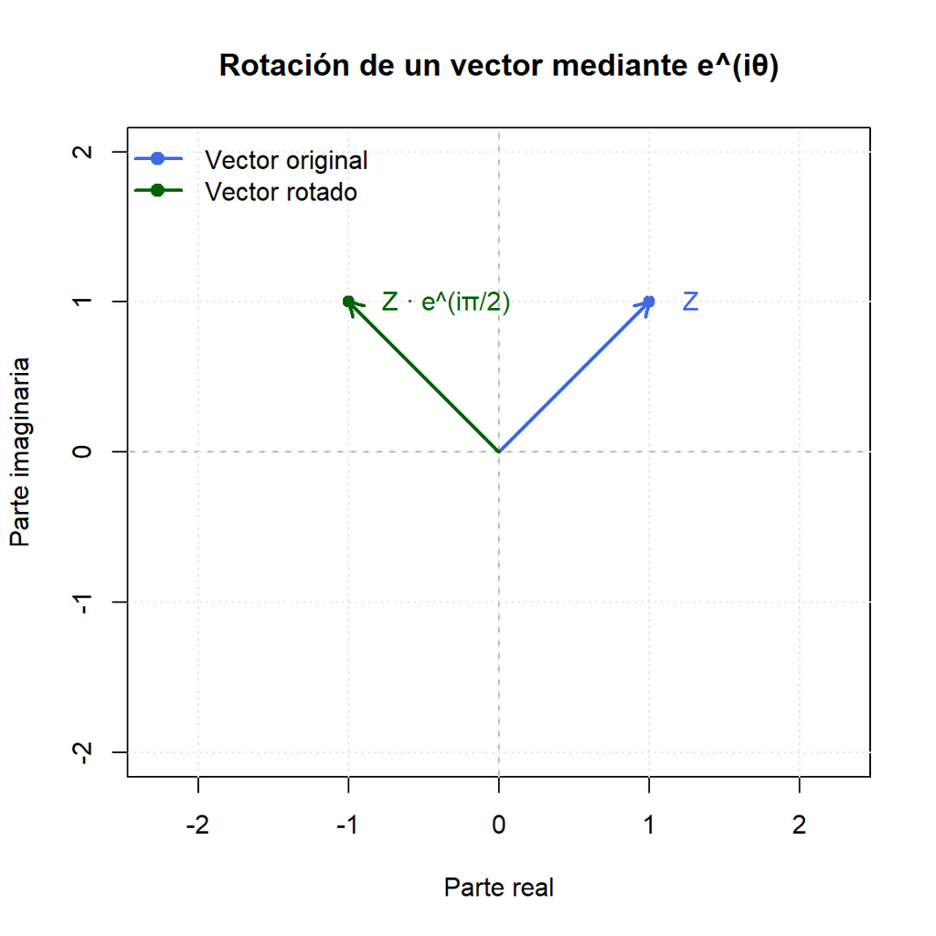

```r
X <- 1
Y <- 1
Z <- complex(real = X, imaginary = Y)


theta <- pi / 2

# Factor de rotación usando Euler
rotation_factor <- complex(real = cos(theta), imaginary = sin(theta))
Z_rotated <- Z * rotation_factor

plot(Re(Z), Im(Z),
     xlim = c(-2, 2), ylim = c(-2, 2),
     xlab = "Parte real", ylab = "Parte imaginaria",
     main = "Rotación de un vector mediante e^(iθ)",
     pch = 19, col = "royalblue",
     asp = 1)

abline(h = 0, v = 0, col = "gray70", lty = 2)
grid(col = "gray90")

arrows(0, 0, Re(Z), Im(Z), col = "royalblue", lwd = 2, length = 0.1)
points(Re(Z_rotated), Im(Z_rotated), pch = 19, col = "darkgreen")
arrows(0, 0, Re(Z_rotated), Im(Z_rotated), col = "darkgreen", lwd = 2, length = 0.1)

text(Re(Z) + 0.12, Im(Z), labels = "Z", col = "royalblue", pos = 4)
text(Re(Z_rotated) + 0.12, Im(Z_rotated), labels = "Z · e^(iπ/2)", col = "darkgreen", pos = 4)

legend("topleft",
       legend = c("Vector original", "Vector rotado"),
       col = c("royalblue", "darkgreen"),
       pch = 19, lwd = 2, bty = "n")
```

La interpretación geométrica es inmediata: el vector azul y el vector verde tienen la misma longitud, pero distinta orientación. Esto es exactamente lo que más adelante necesitaremos para describir direcciones de movimiento y cambios de rumbo sobre un sistema de coordenadas proyectadas.

### 1.6.2 Localizaciones como números complejos

Si cada localización observada se expresa como un número complejo, entonces una serie de posiciones puede tratarse como una colección de puntos en el plano:

$$z_t = x_t + i y_t$$

La ventaja es que cada punto mantiene simultáneamente su componente horizontal y vertical, pero además puede operar como una sola entidad matemática.

```r
X <- c(3, 4, -2)
Y <- c(0, 3, 2)

Z <- complex(real = X, imaginary = Y)
Z
```

```
## [1]  3+0i  4+3i -2+2i
```

Lo mismo sería

```r
Z <- X + 1i * Y
Z
```

```
## [1]  3+0i  4+3i -2+2i
```

Podemos ver las típicas data.frame con las que trabajamos

Con lo que solemos trabajar

```r
# lo que solemos ver
data.frame(
  x = Re(Z),
  y = Im(Z))
```

| x | y |
| --- | --- |
| 3 | 0 |
| 4 | 3 |
| -2 | 2 |

Lo ploteamos

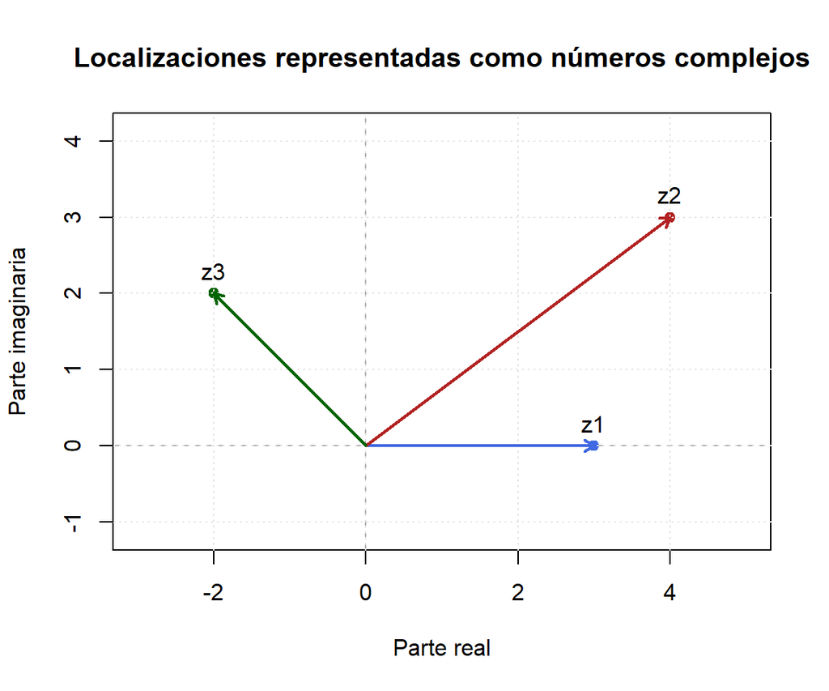

```r
plot(Z,
     pch = 19,
     col = c("royalblue", "firebrick", "darkgreen"),
     asp = 1,
     xlab = "Parte real",
     ylab = "Parte imaginaria",
     main = "Localizaciones representadas como números complejos",
     xlim = c(-3, 5),
     ylim = c(-1, 4))

abline(h = 0, v = 0, col = "gray70", lty = 2)
grid(col = "gray90")

arrows(rep(0, length(Z)),
       rep(0, length(Z)),
       Re(Z), Im(Z),
       lwd = 2,
       col = c("royalblue", "firebrick", "darkgreen"),
       length = 0.08)

text(Re(Z), Im(Z),
     labels = c("z1", "z2", "z3"),
     pos = 3)
```

Cada punto puede verse como un vector desde el origen. En ese contexto, el módulo de cada número complejo es simplemente la distancia euclidiana desde el origen:

$$|z| = \sqrt{x^2 + y^2}$$

Esto muestra con claridad cómo el operador módulo transforma una localización bidimensional en una magnitud real: su longitud.

```r
hip <- sqrt(X^2 + Y^2)
round(hip, 3)
```

```
## [1] 3.000 5.000 2.828
```

```r
# equivalente usando números complejos
Z_mod <- Mod(Z)
round(Z_mod, 3)
```

```
## [1] 3.000 5.000 2.828
```

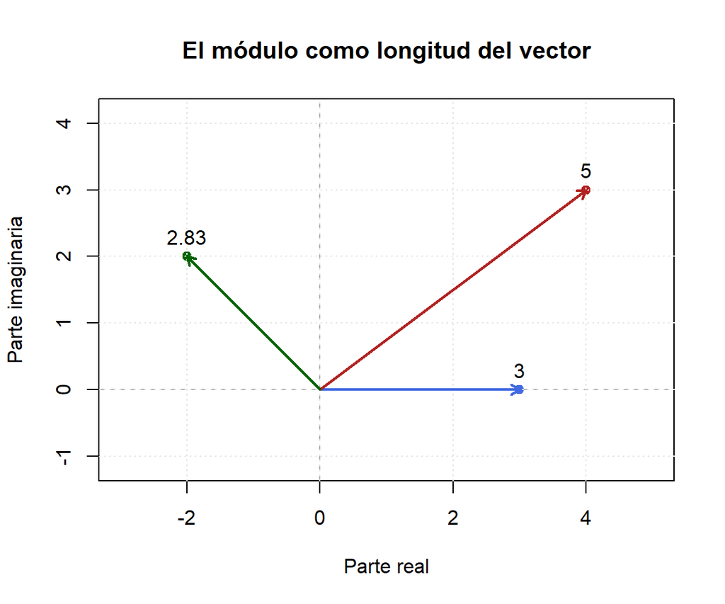

```r
plot(Z,
     pch = 19,
     col = c("royalblue", "firebrick", "darkgreen"),
     asp = 1,
     xlab = "Parte real",
     ylab = "Parte imaginaria",
     main = "El módulo como longitud del vector",
     xlim = c(-3, 5),
     ylim = c(-1, 4))

abline(h = 0, v = 0, col = "gray70", lty = 2)
grid(col = "gray90")

arrows(rep(0, length(Z)),
       rep(0, length(Z)),
       Re(Z), Im(Z),
       lwd = 2,
       col = c("royalblue", "firebrick", "darkgreen"),
       length = 0.08)

text(Re(Z), Im(Z),
     labels = round(Z_mod, 2),
     pos = 3)
```

### 1.6.3 Dirección y argumento

Además de la longitud, cada vector tiene una dirección. En el plano complejo, esa dirección está dada por el argumento:

$$\arg(z)$$

que representa el ángulo del vector con respecto al eje real positivo. En R, este ángulo se obtiene con la función `Arg()`, en radianes.

```r
Arg(Z)
```

```
## [1] 0.0000000 0.6435011 2.3561945
```

```r
Arg(Z) * 180 / pi
```

```
## [1]   0.0000  36.8699 135.0000
```

En términos ecológicos, esta cantidad puede interpretarse como la orientación de un desplazamiento. Más adelante, cuando trabajemos con trayectorias, esta idea permitirá definir la dirección instantánea del movimiento entre dos posiciones consecutivas.

### 1.6.4 De localizaciones a pasos

Supongamos ahora que no queremos medir la localización respecto del origen, sino el movimiento entre observaciones sucesivas. Si una trayectoria está dada por una secuencia de complejos

$$z_1, z_2, z_3, \dots, z_n$$

entonces cada paso se define como

$$\Delta z_t = z_{t+1} - z_t$$

El **largo del paso** será

$$|\Delta z_t|$$

y la **dirección del paso** será

$$\arg(\Delta z_t)$$

A su vez, el **ángulo de giro** entre dos pasos consecutivos puede pensarse como la diferencia entre sus argumentos.

```r
X_path <- c(0, 1, 2, 3, 1, 5, 2, 6)
Y_path <- c(0, 1, 1, 2, 3, 4, 6, 7)

Z_path <- complex(real = X_path, imaginary = Y_path)


steps <- diff(Z_path)


step_length <- Mod(steps)


step_angle <- Arg(steps)


turn_angle <- diff(step_angle)

step_length
```

```
## [1] 1.414214 1.000000 1.414214 2.236068 4.123106 3.605551 4.123106
```

```r
step_angle
```

```
## [1] 0.7853982 0.0000000 0.7853982 2.6779450 0.2449787 2.5535901 0.2449787
```

```r
turn_angle
```

```
## [1] -0.7853982  0.7853982  1.8925469 -2.4329664  2.3086114 -2.3086114
```

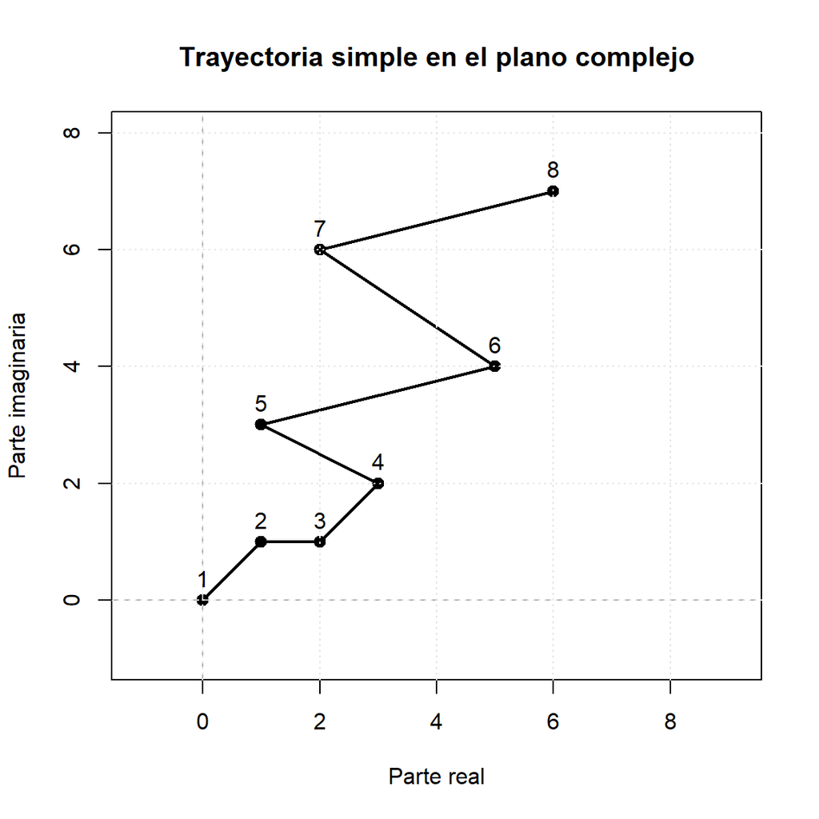

```r
plot(Z_path,
     type = "o",
     pch = 19,
     lwd = 2,
     col = "black",
     asp = 1,
     xlab = "Parte real",
     ylab = "Parte imaginaria",
     main = "Trayectoria simple en el plano complejo",
     xlim = c(0, 8),
     ylim = c(-1, 8))

abline(h = 0, v = 0, col = "gray70", lty = 2)
grid(col = "gray90")

text(Re(Z_path), Im(Z_path),
     labels = seq_along(Z_path),
     pos = 3)
```

En este ejemplo, cada segmento entre puntos consecutivos constituye un paso. El módulo de ese segmento mide cuánto se desplazó el individuo entre dos observaciones, mientras que su argumento indica la dirección de ese desplazamiento. La diferencia entre direcciones consecutivas describe cuánto giró la trayectoria entre un paso y el siguiente.

Esta descomposición en **largos de paso** y **ángulos de giro** es una de las bases del análisis de trayectorias en ecología de movimientos.

### 1.6.5 Trayectoria simulada

Para cerrar esta sección, podemos generar una trayectoria artificial y representar sus localizaciones como números complejos. El objetivo aquí no es construir todavía un modelo biológico realista, sino mostrar cómo una secuencia de coordenadas bidimensionales puede manipularse naturalmente en el plano complejo.

Vamos a generar un ejemplo de cambios unidimensionales en el tiempo.. para esto tenemos que agregar alguito de realidad. Las posiciones de un bicho no son independientes de las anteriores, en la realidad eso nunca pasa (por mas que despues asumamos o no independencia operativa).

Primero generamos una serie temporal mediante un proceso autoregresivo de orden 1 (AR(1)), donde cada valor depende del anterior:

$X_t = \phi X_{t-1} + \varepsilon_t$

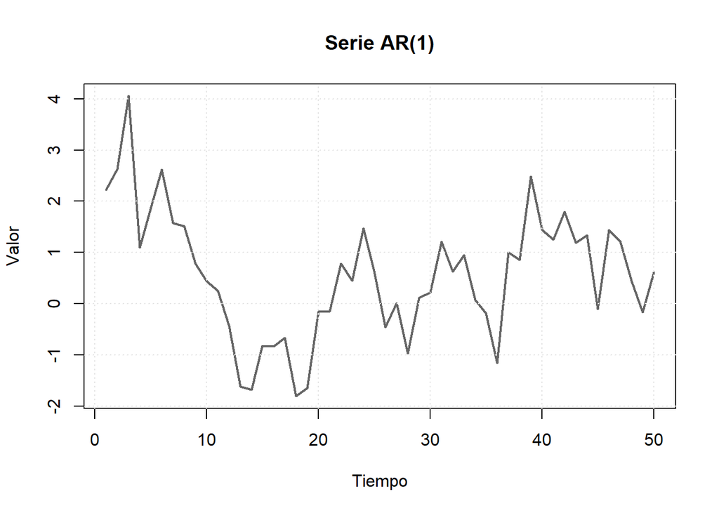

```r
x <- arima.sim(n = 50, model = list(ar = 0.8))

plot(x,
     type = "l",
     lwd = 2,
     col = "gray40",
     main = "Serie AR(1)",
     ylab = "Valor",
     xlab = "Tiempo")

grid(col = "gray90")
```

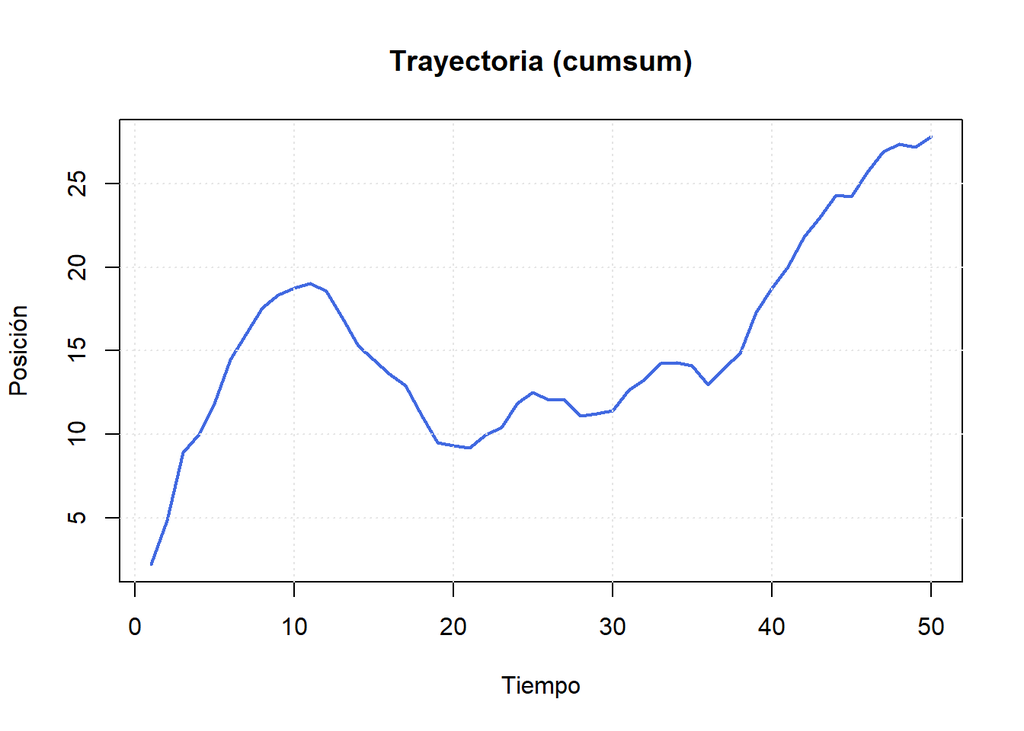

```r
X <- cumsum(x)

plot(X,
     type = "l",
     lwd = 2,
     col = "royalblue",
     main = "Trayectoria (cumsum)",
     ylab = "Posición",
     xlab = "Tiempo")

grid(col = "gray90")
```

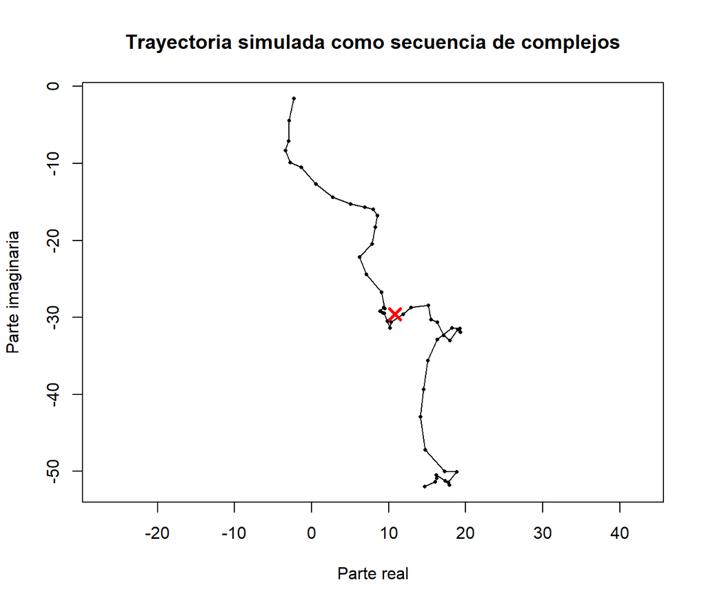

```r
set.seed(123)

X <- cumsum(arima.sim(n = 50, model = list(ar = 0.8)))
Y <- cumsum(arima.sim(n = 50, model = list(ar = 0.8)))

Z <- X + 1i * Y

plot(Z,
     type = "o",
     pch = 16,
     cex = 0.5,
     lwd = 1,
     asp = 1,
     xlab = "Parte real",
     ylab = "Parte imaginaria",
     main = "Trayectoria simulada como secuencia de complejos")

points(mean(Re(Z)), mean(Im(Z)),
       col = "red", pch = 4, cex = 1.5, lwd = 3)
```

En este ejemplo, las coordenadas se generan de manera sintética a partir de procesos estocásticos. Las líneas

[output not shown]

construyen dos series temporales independientes que luego se interpretan como coordenadas espaciales.

Luego, la función `cumsum()` calcula la suma acumulada de esa serie. Esto transforma una secuencia de incrementos (cambios pequeños) en una trayectoria: cada valor nuevo se obtiene sumando el cambio al valor anterior.

Desde el punto de vista del movimiento, esto es clave: en lugar de generar posiciones directamente, estamos generando **desplazamientos sucesivos** que se van acumulando en el espacio.

Al aplicar este procedimiento tanto para *X* como para *Y*, obtenemos dos componentes que evolucionan en el tiempo. Al combinarlas como

$$Z_t = X_t + i Y_t$$

Aquí cada observación de la trayectoria está representada por un número complejo. La serie completa puede analizarse como una secuencia de localizaciones, pero también como una secuencia de desplazamientos complejos obtenidos por diferencias sucesivas.

Esta forma de representar trayectorias será especialmente útil más adelante, cuando trabajemos sobre sistemas de coordenadas cartesianas proyectadas, como UTM, donde las posiciones se expresan justamente sobre un plano en el que estas operaciones tienen interpretación geométrica directa.

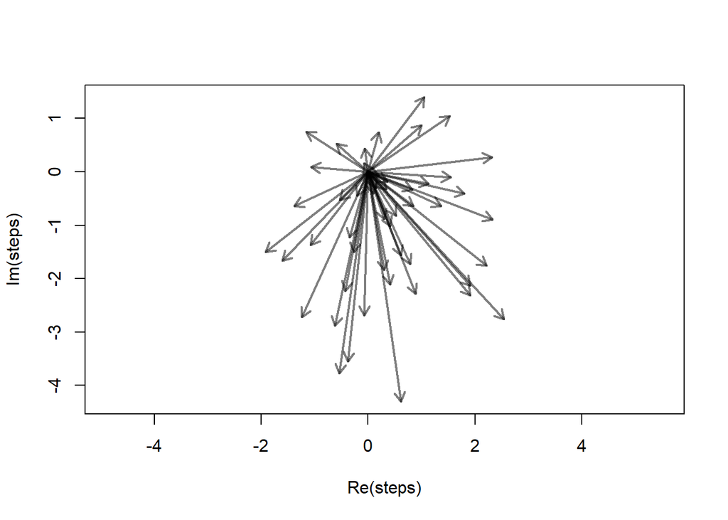

```r
steps <- diff(Z)

plot(steps, asp=1, type="n")
arrows(rep(0, length(steps)),
       rep(0, length(steps)),
       Re(steps), Im(steps),
       col=rgb(0,0,0,.5),
       lwd=2,
       length=0.1)
```

La estrucutra de “arrows” es `arrow(x0, y0, x1, y1)` siendo x0, y0 el punto inicial y el otro el final. entonces repito el inicio ‘n’ veces; siendo n el largo del vector “steps”.

En resumen, lo de arriba nos muestra que steps son vectores, y de los cuales podemos extraer la información clave para describir y luego analizar una trayectoria (o linea conformada por vectores)

```r
step_length <- Mod(steps)

summary(step_length)
```

```
##    Min. 1st Qu.  Median    Mean 3rd Qu.    Max.
##  0.1753  0.9364  1.5483  1.7225  2.4408  4.3459
```

Acá podemos ver claramente que dejamos los números complejos atrás y volvemos a los reales.

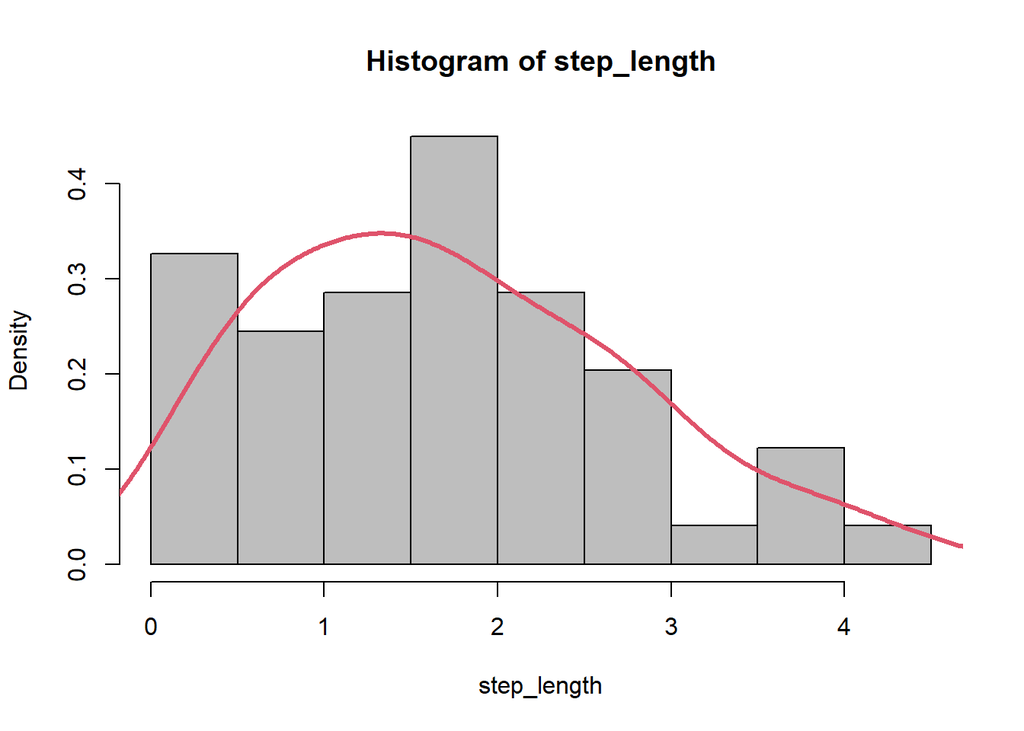

```r
hist(step_length, breaks = 8, col="grey", bor="black", freq=FALSE)
lines(density(step_length), col=2, lwd=3)
```

```r
step_direction <- Arg(steps) # direccion del vector en radianes, respecto al eje X positivo

turning_angle <- diff(step_direction) # también radianes, pero acá toma la direccion del paso anterior y la resta a la del paso actual.

Theta <- diff(turning_angle) # cuanto cambia el giro.. antes vemos cuánto está cambiando la direccion.. ahora si esos cambios de direccion son más o menos fuertes.
```

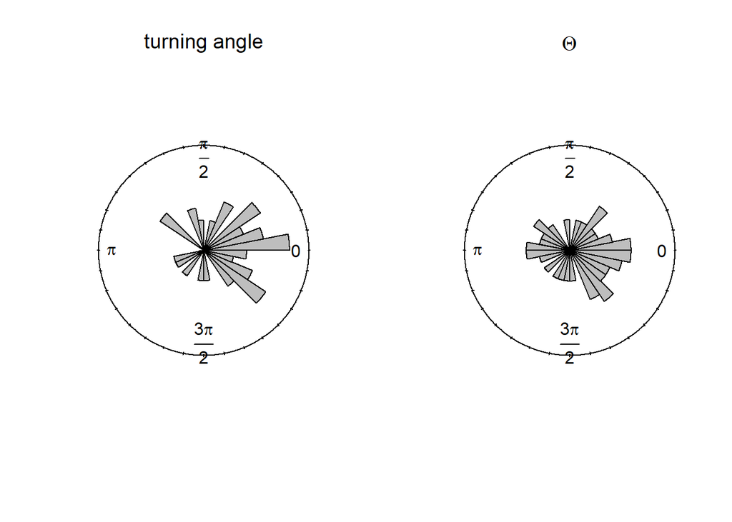

```r
par(mfrow = c(1, 2))

Theta <- circular::as.circular(Theta)
turning_angle <- circular::as.circular(turning_angle)

circular::rose.diag(turning_angle,
                    bins = 32,
                    col = "grey",
                    prop = 2,
                    main = expression(turning~angle))

circular::rose.diag(Theta,
                    bins = 32,
                    col = "grey",
                    prop = 2,
                    main = expression(Theta))
```

```r
par(mfrow = c(1, 1))
```

## 1.7 Operaciones en el plano complejo

Una de las ventajas fundamentales de representar posiciones como números complejos es que las operaciones algebraicas tienen una interpretación geométrica directa.

Si definimos dos localizaciones como

$$Z_1 = X_1 + iY_1 \qquad Z_2 = X_2 + iY_2$$

entonces su suma se define como

$$Z_1 + Z_2 = (X_1 + X_2) + i(Y_1 + Y_2)$$

Esta operación equivale a sumar vectores en el plano, es decir, combinar desplazamientos.

De manera similar, la resta entre complejos representa la diferencia entre posiciones, lo que en ecología de movimientos corresponde directamente a un **desplazamiento**.

#### Traslaciones de una trayectoria

Estas operaciones son especialmente útiles para transformar trayectorias. Por ejemplo, podemos centrar una trayectoria en su media o trasladarla a un nuevo origen sin alterar su forma.

En el siguiente ejemplo, se muestra:

- la trayectoria original,
- la trayectoria centrada en su media,
- y la trayectoria trasladada al punto final.

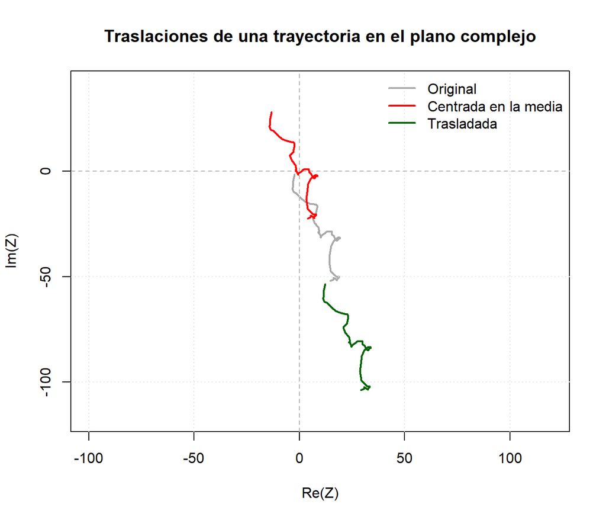

```r
Z_centered <- Z - mean(Z)
Z_shifted  <- Z + Z[length(Z)]

all_re <- c(Re(Z), Re(Z_centered), Re(Z_shifted))
all_im <- c(Im(Z), Im(Z_centered), Im(Z_shifted))

xlim <- range(all_re)
ylim <- range(all_im)


xpad <- diff(xlim) * 0.1
ypad <- diff(ylim) * 0.1

xlim <- xlim + c(-xpad, xpad)
ylim <- ylim + c(-ypad, ypad)

plot(Z,
     asp = 1,
     type = "l",
     col = "darkgray",
     lwd = 2,
     xlab = "Re(Z)",
     ylab = "Im(Z)",
     main = "Traslaciones de una trayectoria en el plano complejo",
     xlim = xlim,
     ylim = ylim)

grid(col = "gray90")
abline(h = 0, v = 0, col = "gray70", lty = 2)


lines(Z_centered,
      col = "red",
      lwd = 2)


lines(Z_shifted,
      col = "darkgreen",
      lwd = 2)

legend("topright",
       legend = c("Original", "Centrada en la media", "Trasladada"),
       col = c("darkgray", "red", "darkgreen"),
       lwd = 2,
       bty = "n")
```

Lo podemos rotar

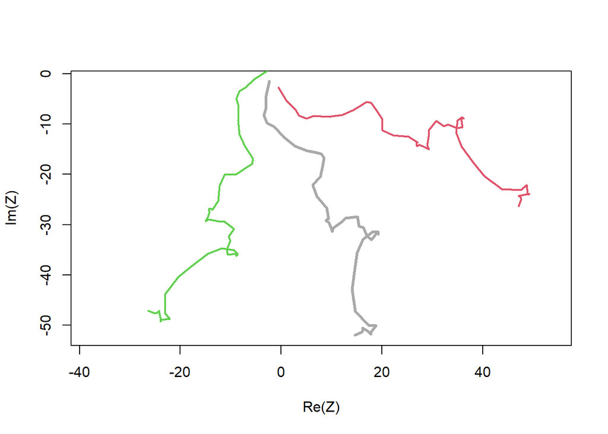

```r
theta1 <- complex(mod=1, arg=pi/4)
theta2 <- complex(mod=1, arg=-pi/4)

plot(Z, asp=1, type="l", col="darkgrey", lwd=3)
lines(Z*theta1, col=2, lwd=2)
lines(Z*theta2, col=3, lwd=2)
```

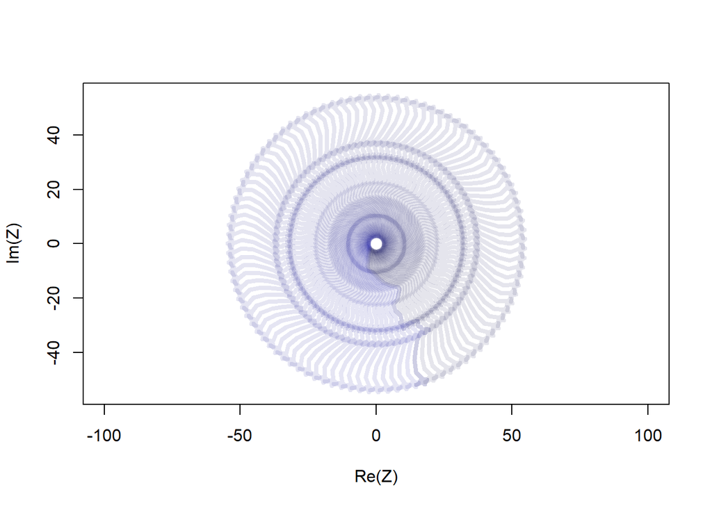

```r
require(gplots)
plot(Z, asp=1, type="n", xlim=c(-1,1)*max(Mod(Z)), ylim=c(-1,1)*max(Mod(Z)))
cols <- rich.colors(1000,alpha=0.1)
thetas <- seq(0,2*pi,length=100)
for(i in 1:1000)
  lines(Z*complex(mod=1, arg=thetas[i]), col=cols[i], lwd=4)
```

Flashero

### 1.6.7 Pasos relativos y rotación al marco local de movimiento

Hasta ahora describimos cada desplazamiento mediante su longitud y su dirección absoluta en el plano. Es decir, para cada paso calculamos:

$$\Delta Z_t = Z_{t+1} - Z_t$$

su módulo

$$S_t = |\Delta Z_t|$$

y su argumento

$$\Phi_t = \arg(\Delta Z_t)$$

Sin embargo, en muchos problemas de ecología de movimientos no interesa tanto la dirección absoluta respecto de los ejes cartesianos, sino cómo se mueve el individuo respecto de su dirección previa. En otras palabras, interesa describir cada paso en un sistema de referencia local, definido por el paso anterior.

Para eso usamos los ángulos de giro, definidos como la diferencia entre direcciones consecutivas:

$$\Theta_t = \Phi_{t+1} - \Phi_t$$

De esta manera, cada nuevo paso puede representarse por dos cantidades:

- su longitud,
- y su giro respecto del paso previo.

Combinando ambas, construimos un número complejo relativo:

$$R_t = S_{t+1} e^{i\Theta_t}$$

Este número ya no describe el paso en el sistema de coordenadas global, sino en un sistema rotado donde el paso anterior se toma como referencia.

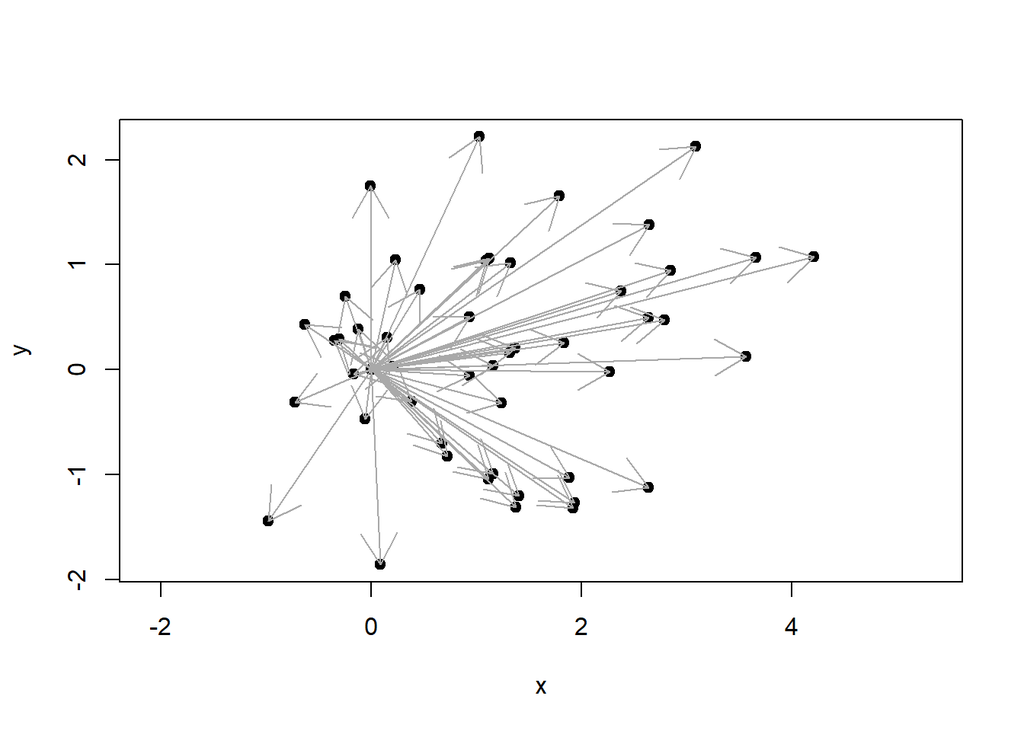

```r
n <- length(Z)
S <- Mod(diff(Z))
Phi <- Arg(diff(Z))
Theta <- diff(Phi)
RelSteps <- complex(mod = S[-1], arg=Theta)

Z0 <- Z[-((n-1):n)]
Z1 <- Z[-c(1,n)]
Z2 <- Z[-(1:2)]

Rotate <- complex(mod = 1, arg=Arg(Z1-Z0))

plot(c(0, RelSteps), asp=1, xlab="x", ylab="y", pch=19)
arrows(rep(0,n-2), rep(0, n-2), Re(RelSteps), Im(RelSteps), col="darkgrey")
```

```r
Z.null <- matrix(0, ncol=n-2, nrow=n-2)
for(i in 1:length(Z1))
  Z.null[i,] <- Z1[i] + RelSteps * Rotate[i]
```

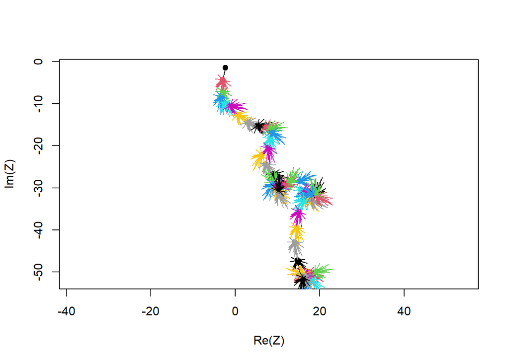

```r
plot(Z, type="o", col=1:length(Z), pch=19, asp=1)
for(i in 1:nrow(Z.null))
  segments(rep(Re(Z1[i]), n-2), rep(Im(Z1[i]), n-2),
           Re(Z.null[i,]), Im(Z.null[i,]), col=i+1)
```

Esto permite visualizar patrones que no son evidentes en el espacio original. Por ejemplo, una alta concentración de pasos alineados indica persistencia direccional, mientras que una dispersión amplia sugiere movimientos más erráticos o exploratorios.

En este sentido, el gráfico no describe la trayectoria en el espacio, sino la **estructura estadística del movimiento**, que es la base de muchos modelos utilizados en ecología de movimientos.

## 1.8 Dimensión temporal

Hasta ahora representamos la trayectoria como una secuencia de números complejos, donde cada elemento contiene una posición en el plano:

$$Z_t = X_t + iY_t$$

Sin embargo, una trayectoria de movimiento no es solo una colección de posiciones, sino una secuencia ordenada en el tiempo. Por eso, es necesario incorporar explícitamente una variable temporal.

En su forma más simple, podemos definir el tiempo como una secuencia numérica creciente:

$$t = 1, 2, 3, \dots, n$$

De esta manera, cada localización queda asociada a un instante temporal, formando una estructura de datos típica en ecología de movimientos: coordenadas espaciales más tiempo.

```r
n <- length(Z)

time <- 1:n

traj_df <- data.frame(
  time = time,
  x = Re(Z),
  y = Im(Z))

head(traj_df)
```

|  | time | x | y |
| --- | --- | --- | --- |
| 1 | 1 | -2.343813 | -1.516166 |
| 2 | 2 | -2.965048 | -4.397040 |
| 3 | 3 | -3.035572 | -7.081966 |
| 4 | 4 | -3.387063 | -8.310911 |
| 5 | 5 | -2.773130 | -9.869413 |
| 6 | 6 | -1.403850 | -10.508251 |

Este `data.frame` representa una trayectoria en su forma más básica: cada fila corresponde a una observación, con su posición en el espacio y su instante en el tiempo.

Esta estructura es la base de prácticamente todos los análisis en ecología de movimientos, ya que permite calcular directamente:

- desplazamientos entre tiempos consecutivos,
- velocidades,
- largos de paso,
- y ángulos de giro.

#### Visualización de la trayectoria con orden temporal

Una forma simple de verificar la estructura es graficar la trayectoria manteniendo el orden temporal de los puntos.

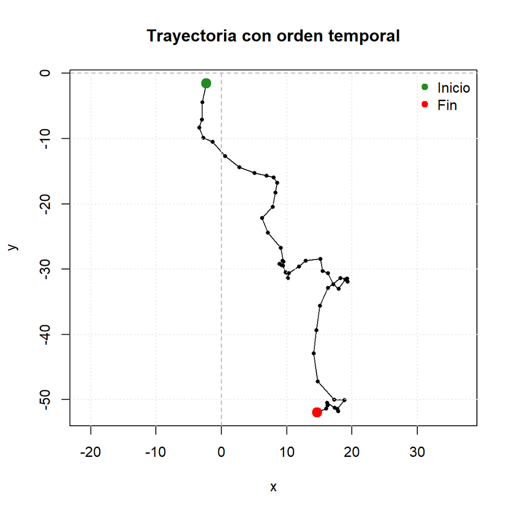

```r
plot(traj_df$x,
     traj_df$y,
     type = "o",
     pch = 16,
     cex = 0.6,
     asp = 1,
     xlab = "x",
     ylab = "y",
     main = "Trayectoria con orden temporal")

grid(col = "gray90")
abline(h = 0, v = 0, col = "gray70", lty = 2)

points(traj_df$x[1], traj_df$y[1], col = "forestgreen", pch = 19, cex = 1.5)
points(traj_df$x[n], traj_df$y[n], col = "red", pch = 19, cex = 1.5)

legend("topright",
       legend = c("Inicio", "Fin"),
       col = c("forestgreen", "red"),
       pch = 19,
       bty = "n")
```

### 1.9 Velocidad y segmentación simple de la trayectoria

Una vez que una trayectoria se organiza como una tabla con coordenadas y tiempo, es posible derivar nuevas variables dinámicas. La más inmediata es la **velocidad**, que mide cuánto cambia la posición por unidad de tiempo.

Si una localización está dada por

$$Z_t = x_t + iy_t$$

entonces el desplazamiento entre dos tiempos consecutivos es

$$\Delta Z_t = Z_{t+1} - Z_t$$

y su longitud,

$$|\Delta Z_t|$$

corresponde al largo del paso. Si además conocemos el intervalo temporal entre observaciones,

$$\Delta t_t = t_{t+1} - t_t$$

la velocidad puede definirse como

$$v_t = \frac{|\Delta Z_t|}{\Delta t_t}$$

En este ejemplo, como el tiempo está dado por una secuencia numérica regular, todos los intervalos valen 1. Por lo tanto, la velocidad coincide numéricamente con el largo de paso, aunque conceptualmente sigue siendo una razón entre distancia y tiempo.

```r
traj_df <- data.frame(
  time = 1:length(Z),
  x = Re(Z),
  y = Im(Z)
)

traj_df$z <- traj_df$x + 1i * traj_df$y

dz <- diff(traj_df$z)


dt <- diff(traj_df$time)


speed <- Mod(dz) / dt


traj_df$speed <- c(NA, speed)

head(traj_df)
```

|  | time | x | y | z | speed |
| --- | --- | --- | --- | --- | --- |
| 1 | 1 | -2.343813 | -1.516166 | -2.343813- 1.516166i | NA |
| 2 | 2 | -2.965048 | -4.397040 | -2.965048- 4.397040i | 2.947095 |
| 3 | 3 | -3.035572 | -7.081966 | -3.035572- 7.081966i | 2.685852 |
| 4 | 4 | -3.387063 | -8.310911 | -3.387063- 8.310911i | 1.278221 |
| 5 | 5 | -2.773130 | -9.869413 | -2.773130- 9.869413i | 1.675065 |
| 6 | 6 | -1.403850 | -10.508251 | -1.403850-10.508251i | 1.510974 |

La nueva columna `speed` resume la rapidez del desplazamiento entre una observación y la siguiente. La primera fila queda con `NA` porque no existe una posición anterior con la cual calcular una diferencia.

#### Clasificación simple de velocidades

Una vez calculada la velocidad, podemos construir una clasificación sencilla en categorías. Esto no constituye todavía un modelo formal de estados de comportamiento, pero sí una primera aproximación a la **segmentación** de la trayectoria.

Aquí dividiremos la velocidad en tres clases:

- **baja**,
- **media**,
- **alta**.

Para hacerlo de manera simple, usaremos cuantiles, de modo que cada categoría contenga aproximadamente un tercio de las observaciones válidas.

```r
cuts <- quantile(traj_df$speed, probs = c(0, 1/3, 2/3, 1), na.rm = TRUE)

traj_df$speed_class <- cut(
  traj_df$speed,
  breaks = cuts,
  include.lowest = TRUE,
  labels = c("baja", "media", "alta")
)

head(traj_df)
```

|  | time | x | y | z | speed | speed_class |
| --- | --- | --- | --- | --- | --- | --- |
| 1 | 1 | -2.343813 | -1.516166 | -2.343813- 1.516166i | NA | NA |
| 2 | 2 | -2.965048 | -4.397040 | -2.965048- 4.397040i | 2.947095 | alta |
| 3 | 3 | -3.035572 | -7.081966 | -3.035572- 7.081966i | 2.685852 | alta |
| 4 | 4 | -3.387063 | -8.310911 | -3.387063- 8.310911i | 1.278221 | media |
| 5 | 5 | -2.773130 | -9.869413 | -2.773130- 9.869413i | 1.675065 | media |
| 6 | 6 | -1.403850 | -10.508251 | -1.403850-10.508251i | 1.510974 | media |

```r
table(traj_df$speed_class, useNA = "ifany")
```

```
##
##  baja media  alta  <NA>
##    17    16    16     1
```

La columna `speed_class` asigna a cada observación una categoría de velocidad. Desde un punto de vista conceptual, esto equivale a pasar de una variable continua a una partición discreta del movimiento, lo que permite identificar segmentos con distinta intensidad de desplazamiento.

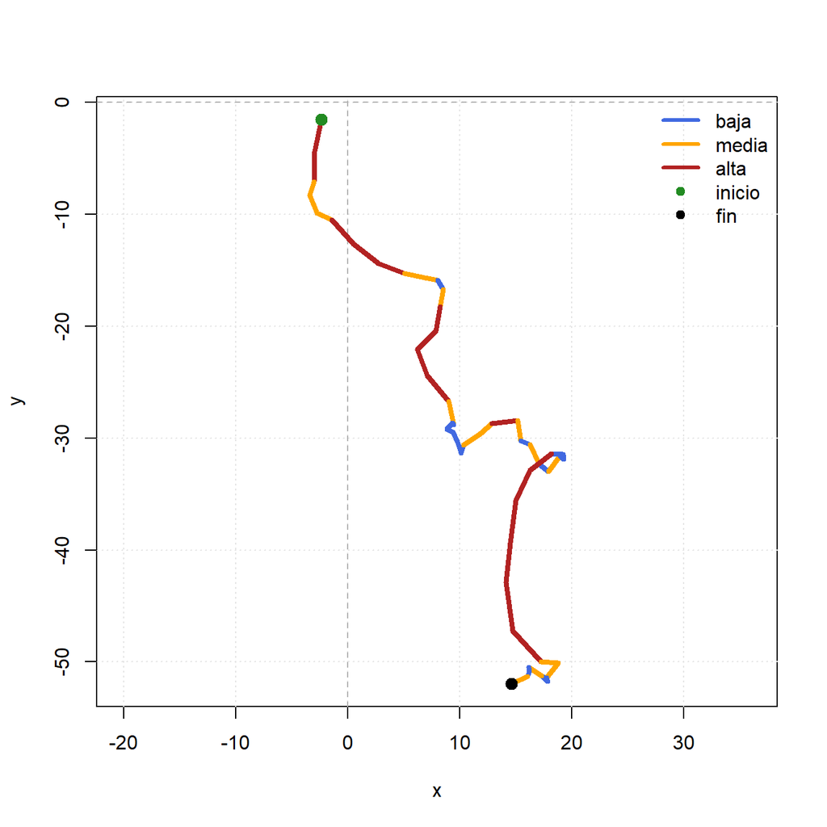

```r
cols <- c("baja" = "royalblue", "media" = "orange", "alta" = "firebrick")

plot(traj_df$x, traj_df$y,
     type = "n",
     asp = 1,
     xlab = "x",
     ylab = "y")

grid(col = "gray90")
abline(h = 0, v = 0, col = "gray70", lty = 2)

for(i in 2:nrow(traj_df)) {
  segments(traj_df$x[i - 1], traj_df$y[i - 1],
           traj_df$x[i], traj_df$y[i],
           col = cols[as.character(traj_df$speed_class[i])],
           lwd = 4)
}


points(traj_df$x[1], traj_df$y[1], pch = 19, col = "forestgreen", cex = 1.3)
points(traj_df$x[nrow(traj_df)], traj_df$y[nrow(traj_df)], pch = 19, col = "black", cex = 1.3)

legend("topright",
       legend = c("baja", "media", "alta", "inicio", "fin"),
       col = c("royalblue", "orange", "firebrick", "forestgreen", "black"),
       lwd = c(3, 3, 3, NA, NA),
       pch = c(NA, NA, NA, 19, 19),
       bty = "n")
```

Este gráfico constituye una primera forma de **segmentación de trayectorias**. En lugar de describir el recorrido como una línea homogénea, cada tramo queda asociado a una categoría de velocidad. Así, comienzan a emerger regiones de movimiento más lento y regiones de movimiento más rápido.

Desde el punto de vista conceptual, esto es importante porque introduce la idea de que una trayectoria puede estar compuesta por distintos **modos de movimiento**. En análisis más avanzados, estas diferencias pueden vincularse con comportamientos como búsqueda localizada, tránsito direccional, descanso o exploración.

Aquí la segmentación es deliberadamente simple y descriptiva, pero sirve como primer paso para entender cómo variables derivadas del movimiento pueden utilizarse para identificar estructura interna en una trayectoria.

**PARENTESISS**

**Estructuras de control en R**

Las instrucciones como `for`, `if` y `while` se llaman **estructuras de control**.

**¿Qué es un `for` loop?**

Un `for` es una estructura de control que permite repetir una misma operación varias veces, cambiando algo en cada iteración.

En R, se escribe así:

`for (i in algo) { … }`

Podés pensarlo como:

**“para cada elemento del objeto, hacé esto”**

```r
for(i in 1:5) {
  print(i)
}
```

```
## [1] 1
## [1] 2
## [1] 3
## [1] 4
## [1] 5
```

Esto dice: “para cada número entre 1 y 5, imprimilo”.

```r
for(i in 1:5) {
  print(i + i/2)
}
```

```
## [1] 1.5
## [1] 3
## [1] 4.5
## [1] 6
## [1] 7.5
```

a Cada elemento sumale su mitad

- **for**: indica repetición
- **i**: variable que va cambiando
- **1:5**: secuencia de valores
- **{ }**: bloque de código que se repite

Cuando hicimos

```r
for(i in 2:nrow(traj_df)) {
  segments(...)
}
```

estamos diciendo:

“para cada paso de la trayectoria, dibujá un segmento entre el punto anterior y el actual”

- i = 2 → conecta punto 1 con 2
- i = 3 → conecta punto 2 con 3
- i = 4 → conecta punto 3 con 4

Así se reconstruye toda la trayectoria.

otro ejemplo de una estrucutra de control de R

```r
x <- 5

if (x > 10) {
  print("grande")
} else {
  print("chico")
}
```

```
## [1] "chico"
```

```r
i <- 1

while (i <= 5) {
  print(i)
  i <- i + 1
}
```

```
## [1] 1
## [1] 2
## [1] 3
## [1] 4
## [1] 5
```

“mientras esto sea cierto, seguí repitiendo”

```r
i <- 1

repeat {
  print(i)

  if (i == 5) {
    break
  }

  i <- i + 1
}
```

```
## [1] 1
## [1] 2
## [1] 3
## [1] 4
## [1] 5
```

```r
x <- 1

repeat {
  x <- x * 2

  if (x > 100) {
    break
  }
}

x
```

```
## [1] 128
```